# Fitting N-of-1 models to data

Ed Baskerville

4/25/2018

This file demonstrates how to fit models to N-of-1 clinical trial simulations. Note that none of these are explicit time-series process models, which is a major limitation.

```r
source('../n1-simulator.R')
library(ggplot2)
```

First, we’ll generate the same time series as in `1-simulation.Rmd`:

```r
result <- n1_simulate(
  n_treatments = 2, n_blocks = 2,
  baseline_initial = 160, effect_size = c(-40, -30), tc_in = c(3, 2), tc_out = c(2, 3), tc_outcome = 1,
  sd_baseline = 0.4, sd_outcome = 0.6, sd_obs = 4.0,
  treatment_period = 30.0, sampling_timestep = 1.0, noise_timestep = 0.01,
  treatment_order = NULL, random_seed = 1, return_data_frame = TRUE
)
timeseries <- result$timeseries
```

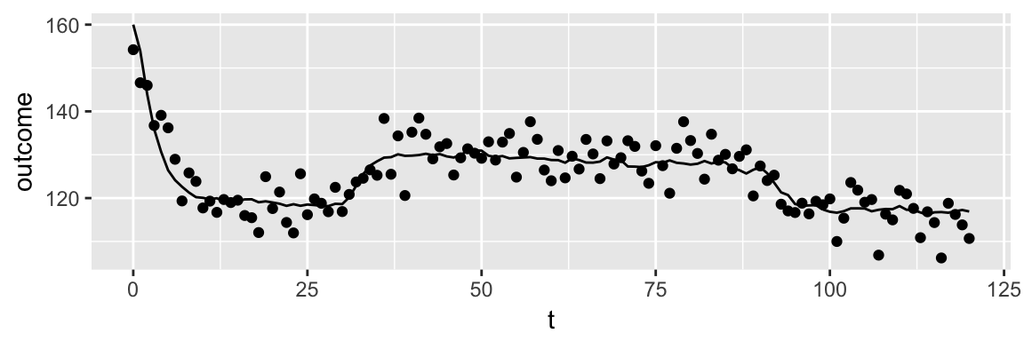

```r
ggplot(data = timeseries, aes(x = t)) + geom_line(aes(y = outcome)) + geom_point(aes(y = outcome_obs))
```

## Model 1: treatment only

```r
lm(outcome_obs ~ factor(treatment), data = timeseries)
```

```
##
## Call:
## lm(formula = outcome_obs ~ factor(treatment), data = timeseries)
##
## Coefficients:
##        (Intercept)  factor(treatment)2
##            120.655               8.599
```

The intercept represents the baseline plus effect of treatment 1, and the coefficient for treatment 2 represents the effect size difference between the two treatments.

This is encapsulated in the function `n1_model1`, which returns a named list containing three items: * `coefficients`: a data frame with effect coefficient estimates in the `estimate` column, and p-values in the `pvalue` column * `fit_obj`: the raw object returned by `lm` * `AIC` the Akaike Information Criterion value (AIC) for the model, for selecting among models

```r
n1_fit_model1(n_treatments = 2, timeseries)
```

```
## $coefficients
##                      estimate        pvalue
## (Intercept)        120.654537 2.236442e-130
## factor(treatment)2   8.599241  1.471748e-09
##
## $AIC
## [1] 480.0736
##
## $fit_obj
##
## Call:
## lm(formula = outcome_obs ~ factor(treatment), data = data)
##
## Coefficients:
##        (Intercept)  factor(treatment)2
##            120.655               8.599
```

## Model 2: treatment + block

Model 2 adds a per-block regression term:

```r
lm(outcome_obs ~ factor(treatment) + factor(block), data = timeseries)
```

```
##
## Call:
## lm(formula = outcome_obs ~ factor(treatment) + factor(block),
##     data = timeseries)
##
## Coefficients:
##        (Intercept)  factor(treatment)2      factor(block)2
##            122.530               8.569              -3.690
```

A shortcut is provided as `n1_model2`:

```r
n1_fit_model2(n_treatments = 2, timeseries)
```

```
## $coefficients
##                      estimate        pvalue
## (Intercept)        122.529798 3.575562e-121
## factor(treatment)2   8.568994  6.273916e-10
##
## $AIC
## [1] 473.7393
##
## $fit_obj
##
## Call:
## lm(formula = outcome_obs ~ factor(treatment) + factor(block),
##     data = data)
##
## Coefficients:
##        (Intercept)  factor(treatment)2      factor(block)2
##            122.530               8.569              -3.690
```

Note the lower AIC value for this model, indicating that baseline drift is detected.

## Model 3: treatment + block + treatment * time

Model 3 adds an interaction with time:

```r
lm(outcome_obs ~ factor(treatment) + t * factor(treatment) + factor(block), data = timeseries)
```

```
##
## Call:
## lm(formula = outcome_obs ~ factor(treatment) + t * factor(treatment) +
##     factor(block), data = timeseries)
##
## Coefficients:
##          (Intercept)    factor(treatment)2                     t
##            126.48750               3.37838              -0.11115
##       factor(block)2  factor(treatment)2:t
##              1.75250               0.08613
```

and gives analogous results with `n1_fit_model3`:

```r
n1_fit_model3(n_treatments = 2, timeseries)
```

```
## $coefficients
##                      estimate        pvalue
## (Intercept)        126.487501 2.978448e-107
## factor(treatment)2   3.378377  4.351799e-01
##
## $AIC
## [1] 461.7158
##
## $fit_obj
##
## Call:
## lm(formula = outcome_obs ~ factor(treatment) + t * factor(treatment) +
##     factor(block), data = data)
##
## Coefficients:
##          (Intercept)    factor(treatment)2                     t
##            126.48750               3.37838              -0.11115
##       factor(block)2  factor(treatment)2:t
##              1.75250               0.08613
```

Again, note that the AIC value shows an improvement over the simpler models.

## Model 4: treatment + block mixed effect

Model 4 is a mixed-effect model, and requires the `nlme` package:

```r
library(nlme)
lme(fixed = (outcome_obs ~ factor(treatment)), random = (~ 1 | block), data = timeseries, method = 'ML')
```

```
## Linear mixed-effects model fit by maximum likelihood
##   Data: timeseries
##   Log-likelihood: -408.0149
##   Fixed: (outcome_obs ~ factor(treatment))
##        (Intercept) factor(treatment)2
##         120.677654           8.576124
##
## Random effects:
##  Formula: ~1 | block
##         (Intercept) Residual
## StdDev:    1.612971 6.966694
##
## Number of Observations: 121
## Number of Groups: 2
```

and it is accessible via `n1_fit_model4`:

```r
n1_fit_model4(n_treatments = 2, timeseries)
```

```
## $coefficients
##                      estimate        pvalue
## (Intercept)        120.677654 2.723496e-106
## factor(treatment)2   8.576124  6.998566e-10
##
## $AIC
## [1] 824.0297
##
## $fit_obj
## Linear mixed-effects model fit by maximum likelihood
##   Data: data
##   Log-likelihood: -408.0149
##   Fixed: (outcome_obs ~ factor(treatment))
##        (Intercept) factor(treatment)2
##         120.677654           8.576124
##
## Random effects:
##  Formula: ~1 | block
##         (Intercept) Residual
## StdDev:    1.612971 6.966694
##
## Number of Observations: 121
## Number of Groups: 2
```

The AIC value is bizarrely high.